# R Tutorial at the WZB

December 06, 2018

## Today's schedule

1. Review of last week's tasks
2. Reshaping data with `gather()` and `spread()`
3. Plotting with *ggplot2*

## Review of last week's tasks

## Solution for tasks #6

now online on https://wzbsocialsciencecenter.github.io/wzb_r_tutorial/

## Reshaping data with `gather()` and `spread()`

## Tidy data

Hadley Wickham introduced the concept of **tidy data** as a way how data should be organized so it is comfortable to work with ([H. Wickham 2014: Tidy Data](http://www.jstatsoft.org/v59/i10/paper)). He defined three rules that make a data set tidy:

1. Each variable must have its own column.
2. Each observation must have its own row.
3. Each value must have its own cell.

source: [Grolemund, Wickham 2017: R for Data Science](http://r4ds.had.co.nz/tidy-data.html#introduction-6)

## Why tidy data?

- a tidy data set allows for easier variable selection, grouping, summarization and visualization
- tools and packages in the *tidyverse* like *dplyr* or *ggplot2* require data to be organized in that way
- the problem: most data you'll get won't be "tidy" from the beginning on → you'll need to reshape it

## Reshaping untidy data

**`OBrienKaiser` from package *carData***

- data from imaginary study
- three treatments: A, B, control
- three measurement types: pretest, posttest, follow-up session
- each measured at five occasions (suffixes `.1` to `.5`)

```
 treatment gender pre.1 pre.2 pre.3 pre.4 pre.5 post.1 post.2 post.3 post.4 post.5 fup.1 ...
         A      M     7     8     7     9     9      9      9     10      8      9     9 ...
         B      F     4     5     7     5     4      7      7      8      6      7     7 ...
   control      M     1     2     4     2     1      3      2      5      3      2     2 ...
       ...
```

Is this data *tidy*?

**No!** You have **several measurements (observations) per row**. This is also called a *wide table format*.

→ hard to work with (e.g. compute mean of all three measurement types separately)

## Reshaping untidy data

We can use `gather()` from package *tidyr* to put the measurements in separate rows.

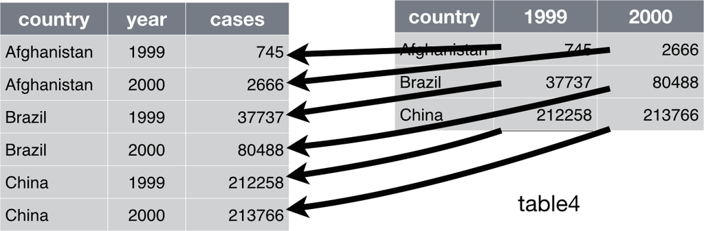

source: [Grolemund, Wickham 2017: R for Data Science](http://r4ds.had.co.nz/tidy-data.html#gathering)

## Reshaping untidy data

`gather()` takes the following arguments (among others):

1. The data to work with (omit this if you use the pipe operator `%>%`).
2. The "untidy" columns to gather.
3. `key`: The name of the new column containing the measurement types.
4. `value`: The name of the new column containing the measurement values.

```r
(tidy_obk <- gather(OBrienKaiser, pre.1:fup.5,
                    key = 'meas_type_occasion', value = 'value'))
```

```
##     treatment gender meas_type_occasion value
## 1     control      M              pre.1     1
## 2     control      M              pre.1     4
## 3     control      M              pre.1     5
## 4     control      F              pre.1     5
## 5     control      F              pre.1     3
## 6           A      M              pre.1     7
## 7           A      M              pre.1     5
## 8           A      F              pre.1     2
## 9           A      F              pre.1     3
## 10          B      M              pre.1     4
## 11          B      M              pre.1     3
## 12          B      M              pre.1     6
## 13          B      F              pre.1     5
## 14          B      F              pre.1     2
## 15          B      F              pre.1     2
##  [ reached getOption("max.print") -- omitted 225 rows ]
```

## Reshaping untidy data

Our data is already better to work with, but `meas_type_occasion` still contains two values like "pre.1" (pretest 1) or "fup.4" (follow-up test 4). This violates rule #3: *"Each value must have its own cell."*).

We can use `separate()` (package *tidyr*) to split columns that contain several values. It takes the following arguments (among others):

1. The data to work with (omit this if you use the pipe operator `%>%`).
2. The column to split.
3. `into`: The names of the new columns.
4. `sep`: A rule for how to split the values. The default is to split on anything that is not a number or character (e.g. slash, period, hyphen, …).

```r
tidy_obk <- separate(tidy_obk, meas_type_occasion,
                      into = c('meas_type', 'meas_occasion'))
```

## Reshaping untidy data

Some additional variable conversion and we're done:

```r
tidy_obk <- mutate(tidy_obk,
                   meas_type = factor(meas_type, levels = c('pre', 'post', 'fup')),
                   meas_occasion = as.integer(meas_occasion))
```

```
##     treatment gender meas_type meas_occasion value
## 1     control      M       pre             1     1
## 2     control      M       pre             1     4
## 3     control      M       pre             1     5
## 4     control      F       pre             1     5
## 5     control      F       pre             1     3
## 6           A      M       pre             1     7
## 7           A      M       pre             1     5
## 8           A      F       pre             1     2
## 9           A      F       pre             1     3
## 10          B      M       pre             1     4
## 11          B      M       pre             1     3
## 12          B      M       pre             1     6
##  [ reached getOption("max.print") -- omitted 228 rows ]
```

→ This is tidy data. It's also called the *long table format*.

## Reshaping untidy data

With *this* data we can actually work!

```r
tidy_obk %>%
  group_by(treatment, meas_type) %>%
  summarise(mean_measurement = mean(value))
```

```
## # A tibble: 9 x 3
## # Groups:   treatment [?]
##   treatment meas_type mean_measurement
##   <fct>     <fct>                <dbl>
## 1 control   pre                   4.2
## 2 control   post                  4
## 3 control   fup                   4.4
## 4 A         pre                   5
## 5 A         post                  6.5
## 6 A         fup                   7.25
## 7 B         pre                   4.14
## 8 B         post                  6.57
## 9 B         fup                   7.29
```

**It's better spending some time on data cleanup than struggling with messy data sets!**

## Combining rows

`spread()` is the opposite of `gather()`: It combines observations from multiple rows into a single row with more columns. Hence it converts data from the long table format to the wide table format.

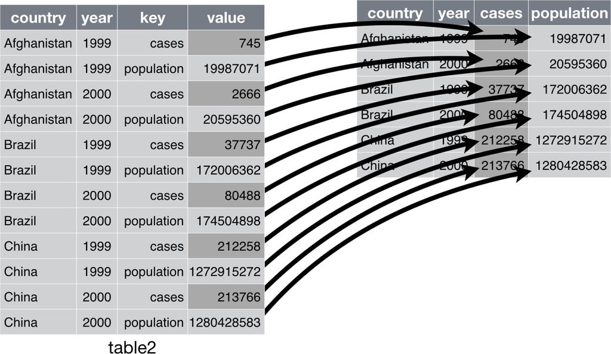

source: [Grolemund, Wickham 2017: R for Data Science](http://r4ds.had.co.nz/tidy-data.html#spreading)

## Combining rows

`economics_long` from package *ggplot2* contains data in long table format:

```
   date       variable    value
   1967-07-01 pce         507.
   1967-08-01 pce         510.
   1967-09-01 pce         516.
   ...
   1967-07-01 pop      198712
   1967-08-01 pop      198911
   1967-09-01 pop      199113
   ...
   1967-07-01 psavert      12.5
   1967-08-01 psavert      12.5
   1967-09-01 psavert      11.7
   ...
```

For each date, there are five variable types (pce, pop, psavert, unemploy, uempmed) and their respective values.

## Combining rows

`spread()` takes the following arguments:

1. The data to work with (omit this if you use the pipe operator `%>%`).
2. `key`: The column containing the variable names.
3. `value`: The column containing the respective variable values.

```r
spread(economics_long, variable, value)
```

```
## # A tibble: 574 x 6
##    date         pce    pop psavert uempmed unemploy
##    <date>     <dbl>  <dbl>   <dbl>   <dbl>    <dbl>
##  1 1967-07-01  507. 198712    12.5     4.5     2944
##  2 1967-08-01  510. 198911    12.5     4.7     2945
##  3 1967-09-01  516. 199113    11.7     4.6     2958
##  4 1967-10-01  513. 199311    12.5     4.9     3143
##  5 1967-11-01  518. 199498    12.5     4.7     3066
##  6 1967-12-01  526. 199657    12.1     4.8     3018
##  7 1968-01-01  532. 199808    11.7     5.1     2878
##  8 1968-02-01  534. 199920    12.2     4.5     3001
##  9 1968-03-01  545. 200056    11.6     4.1     2877
## 10 1968-04-01  545. 200208    12.2     4.6     2709
## # ... with 564 more rows
```

## Plotting with ggplot2

## Data visualization

Grouping, aggregating and summarizing results are important for data analysis. They let you reduce complex data sets to simpler summarizations, compare groups and help to see patterns in your data.

Visualization of your data can have the same benefits and has the power to communicate a message much faster than a table of numbers. However, it requires a **sense for which type of graph or visual representation is appropriate for your data**.

A useful website for inspiration, code examples and caveats is https://www.data-to-viz.com.

## What is *ggplot2*?

[figure not shown]

source: [tidyverse.org](https://www.tidyverse.org/)

- R offers several plotting systems (e.g. base R, *lattice* or *ggplot2*)
- we'll use *ggplot2* because:
  - it's versatile and elegant
  - it employs a well founded theory for declaratively creating graphics called *"Grammar of Graphics"* (Wilkinson 2005)
  - it's part of the *tidyverse* → plays together well with the tools we already learned

## General concepts behind *ggplot2*

There are three basic steps for constructing plots with *ggplot2*:

1. Supply a data set you want to plot to `ggplot()`.
2. Define an **aesthetic mapping** with `aes()`.  
   This describes how variables of your data are mapped to visual properties, e.g. variable "age" is plotted on the x-axis and "income" on the y-axis.
3. Add layers of **geoms** (geometrical objects) that describe which graphical primitives to use (e.g. points in a scatter plot or bars in a bar plot).

Additionally, you can further change the appearance of your plot by:

- altering the **scales** (e.g. use a logarithmic scale, modify display of factors, etc.)
- defining **facets** → create *small multiples*, each showing a different subset of the data
- changing the **coordinate system** (e.g. to display maps or radial plots)
- changing the overall appearance of the plot by adjusting its **theme** (e.g. change background color, rotate axis labels, etc.)

You combine all these steps with a `+`.

## General concepts behind *ggplot2*

We'll make a plot for historical election results from four states (data set `presidentialElections` from package *pscl*):

```
## # A tibble: 88 x 4
##    state        demVote  year south
##    <chr>          <dbl> <int> <lgl>
##  1 Louisiana       92.8  1932 TRUE
##  2 Maine           43.2  1932 FALSE
##  3 South Dakota    63.6  1932 FALSE
##  4 Tennessee       66.5  1932 TRUE
##  5 Louisiana       88.8  1936 TRUE
##  6 Maine           41.5  1936 FALSE
##  7 South Dakota    54.0  1936 FALSE
##  8 Tennessee       68.8  1936 TRUE
##  9 Louisiana       85.9  1940 TRUE
## 10 Maine           48.8  1940 FALSE
## # ... with 78 more rows
```

## General concepts behind *ggplot2*

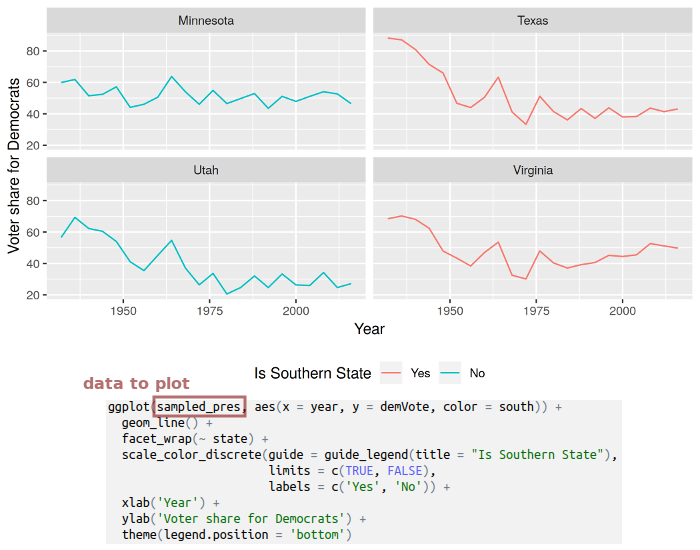

## General concepts behind *ggplot2*

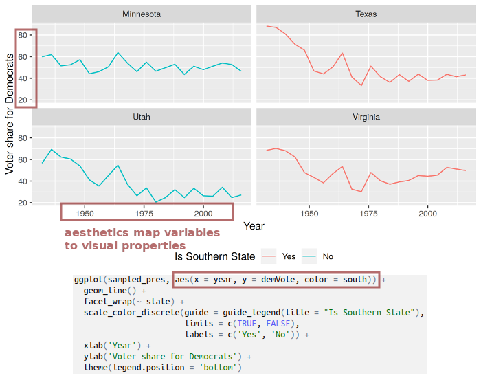

## General concepts behind *ggplot2*

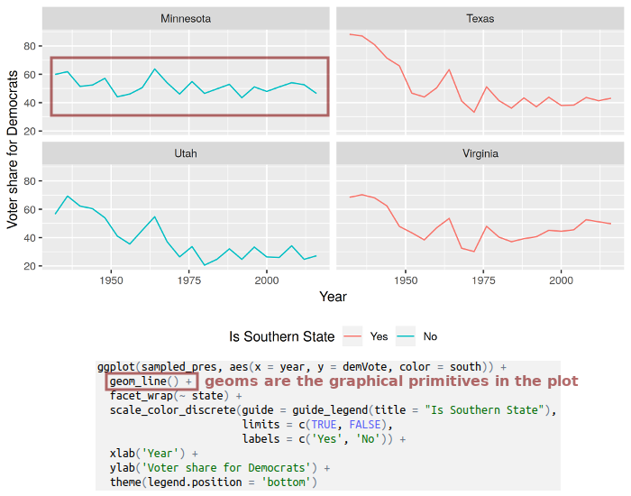

## General concepts behind *ggplot2*

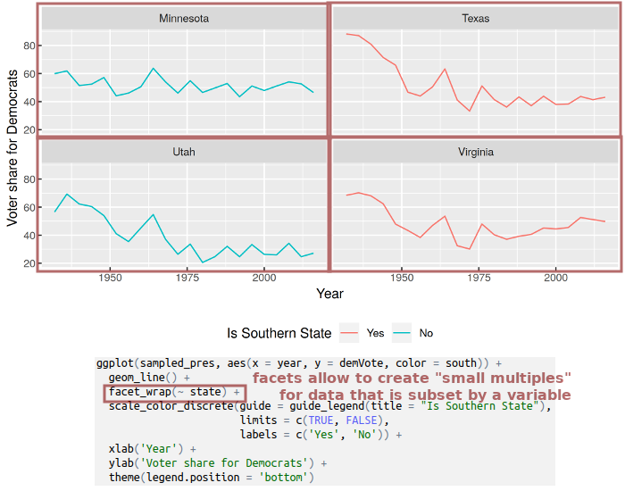

## General concepts behind *ggplot2*

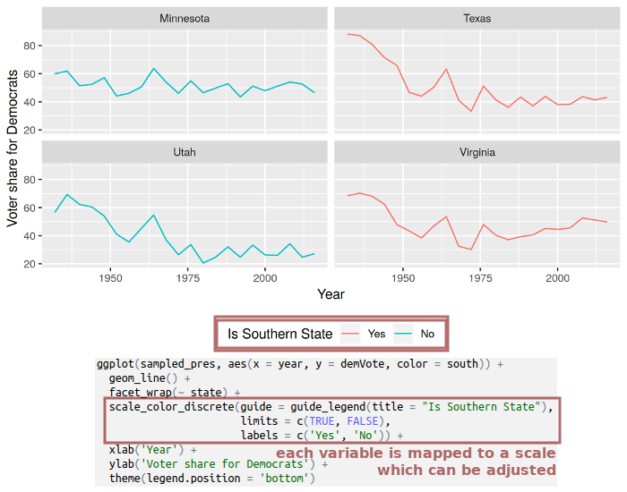

## General concepts behind *ggplot2*

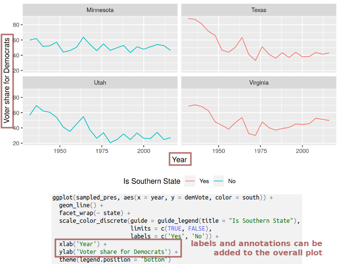

## General concepts behind *ggplot2*

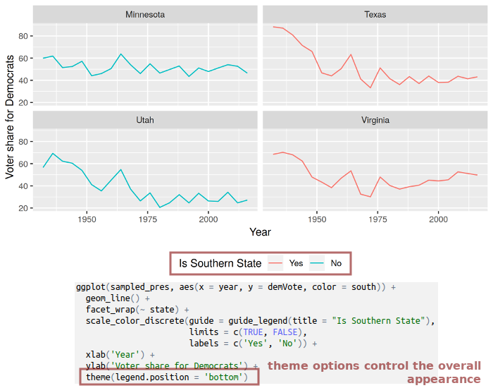

## Example data

Example data: `politicalInformation` from *pscl* package

> Interviewers administering the 2000 American National Election Studies assigned an ordinal rating to each respondent's "general level of information" about politics and public affairs.

```
##                y collegeDegree female age homeOwn govt length  id
## 1    Fairly High           Yes     No  49     Yes   No  58.40   1
## 2        Average            No    Yes  35     Yes   No  46.15   2
## 3      Very High            No    Yes  57     Yes   No  89.52   3
## 4        Average            No     No  63     Yes   No  92.63   4
## 5    Fairly High           Yes    Yes  40     Yes   No  58.85   4
## 6        Average            No     No  77     Yes   No  53.82   4
## 7        Average            No     No  43     Yes   No  58.47   5
##  [ reached getOption("max.print") -- omitted 1800 rows ]
```

## Distribution of a single variable

At first, you should make sure that you either loaded the *tidyverse* package or *ggplot2* package. We define:

1. The data set `politicalInformation`.
2. The aeshetic mapping for a single variable `age`.
3. The graphical representation as histogram with `geom_histogram()`.

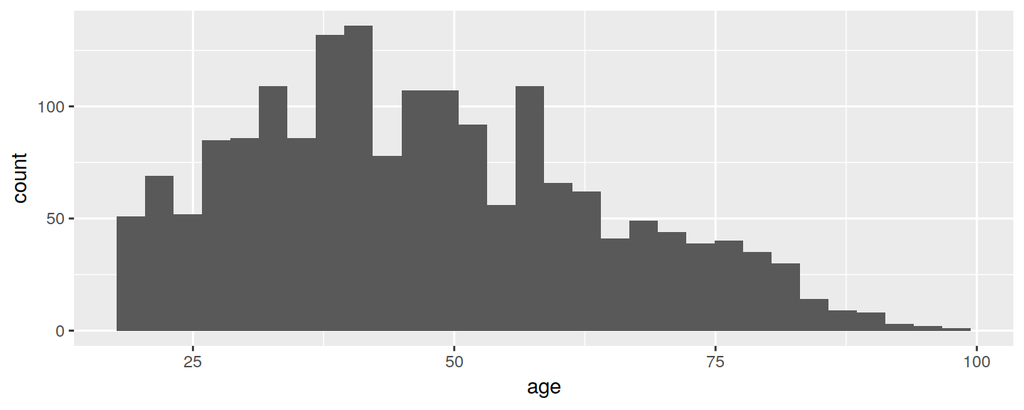

```r
ggplot(politicalInformation, aes(age)) + geom_histogram()
```

## Distribution of a single variable

I hid two messsages produced by ggplot:

```
`stat_bin()` using `bins = 30`. Pick better value with `binwidth`.
Removed 9 rows containing non-finite values (stat_bin).
```

- the first tells us that a default value for the number of bins was used → we set `binwidth = 5` below to make a histogram of age with five-year steps
- the second complains about 9 NA values in the `age` variable → we can ignore this

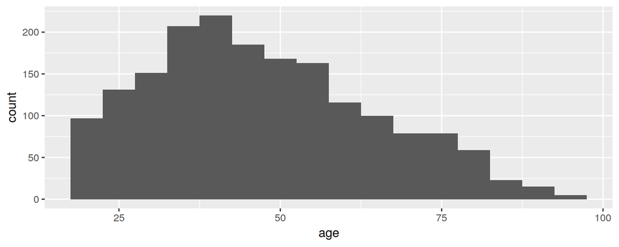

```r
ggplot(politicalInformation, aes(age)) + geom_histogram(binwidth = 5)
```

## Distribution of a single variable

What if we wanted to know if the distribution of `age` in our sample is different for men and women?

We can produce *boxplots* for both subsets, putting `female` on the x-axis (see how the aesthetics mapping was changed!):

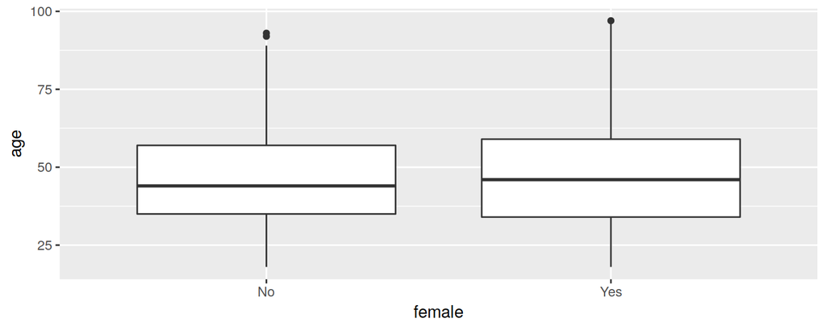

```r
ggplot(politicalInformation, aes(x = female, y = age)) + geom_boxplot()
```

## Distribution of a single variable

A *violin plot* offers better insight about the actual shape of the distribution:

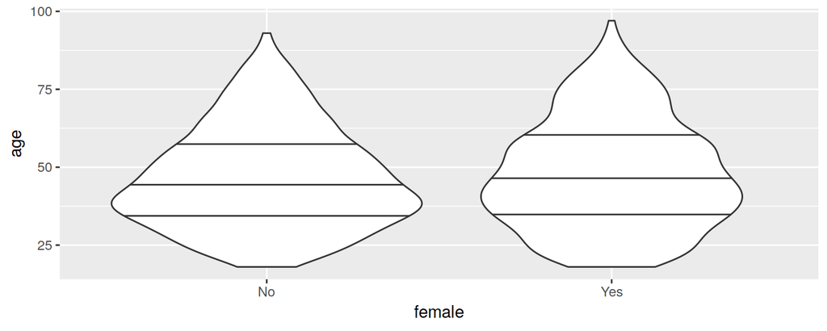

```r
ggplot(politicalInformation, aes(x = female, y = age)) +
  geom_violin(draw_quantiles = c(0.25, 0.5, 0.75))  # horizontal lines for quartiles
```

## Distribution of a single variable

A *density plot* also reveals that there are more younger men in the sample:

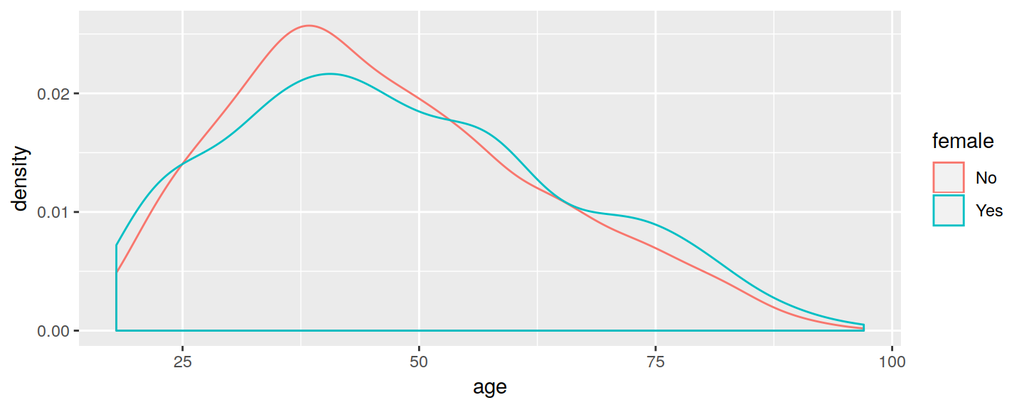

```r
ggplot(politicalInformation, aes(age, color = female)) + geom_density()
```

## Counts of a single categorical variable

Histograms can be used to bin continuous variables. To show the distribution of a categorical variable we can use a simple *bar chart*:

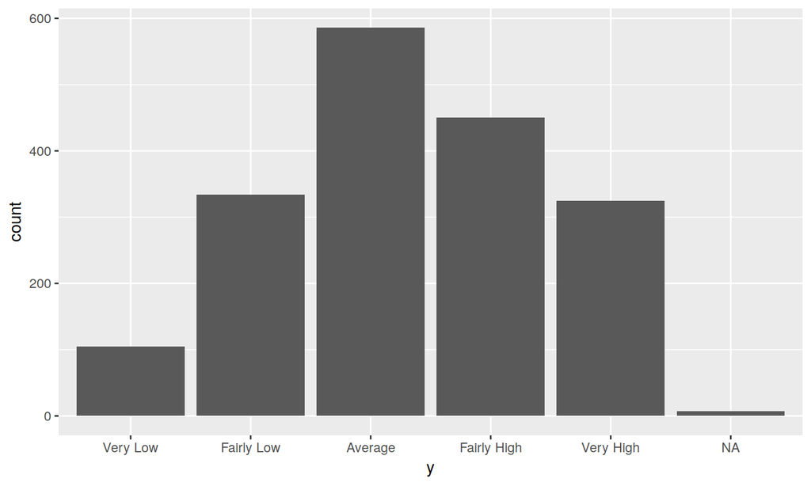

```r
ggplot(politicalInformation, aes(y)) + geom_bar()
```

## Counts of a single categorical variable

A *stacked* and *grouped* bar charts allows to compare groups. Here, we compare groups based on the `collegeDegree` variable by mapping the "fill (color)" aesthetic to it.

By default, the bars get stacked:

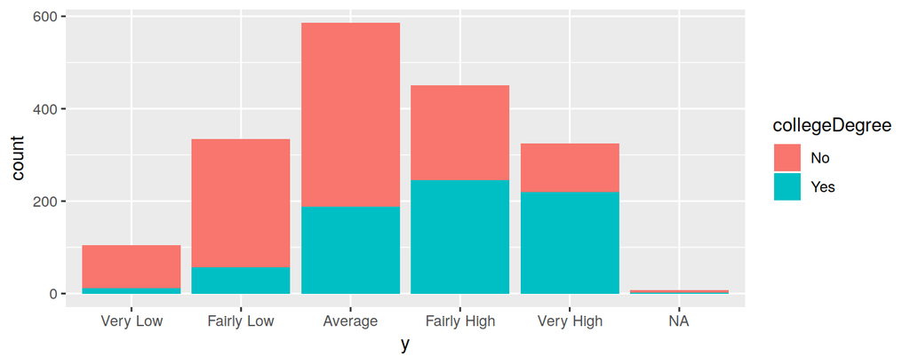

```r
ggplot(politicalInformation, aes(y, fill = collegeDegree)) +
  geom_bar()
```

## Counts of a single categorical variable

A *stacked* and *grouped* bar charts allows to compare groups. Here, we compare groups based on the `collegeDegree` variable by mapping the "fill (color)" aesthetic to it.

Setting the bars' `position` to `position_dodge()` creates a grouped bar chart:

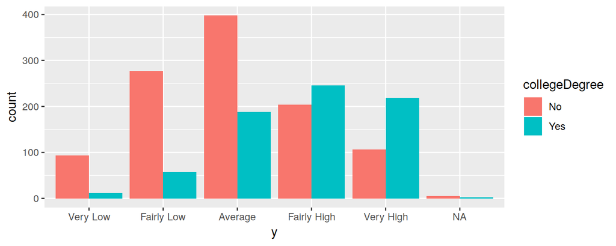

```r
ggplot(politicalInformation, aes(y, fill = collegeDegree)) +
  geom_bar(position = position_dodge())
```

## Scatterplots

A *scatterplot* displays the relationship between two numeric variables. We'll use the `airquality` and have a look at the relationship between ozone and temperature.

```r
head(airquality)
```

```
##   Ozone Solar.R Wind Temp Month Day
## 1    41     190  7.4   67     5   1
## 2    36     118  8.0   72     5   2
## 3    12     149 12.6   74     5   3
## 4    18     313 11.5   62     5   4
## 5    NA      NA 14.3   56     5   5
## 6    28      NA 14.9   66     5   6
```

## Scatterplots

A *scatterplot* displays the relationship between **two numeric variables**. We'll use the `airquality` and have a look at the relationship between ozone and temperature.

We map `Ozone` to the y-axis and `Temp` to the x-axis and use `geom_point()`:

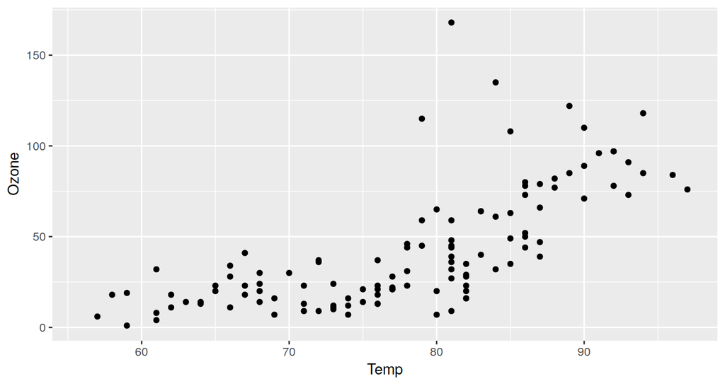

```r
ggplot(airquality, aes(x = Temp, y = Ozone)) + geom_point()
```

## Scatterplots

*Overplotting* can easily occur, especially with large data sets.

- happens when multiple data points are drawn on the same spot
- fix it with setting a semi-transparent fill color or apply *jittering*

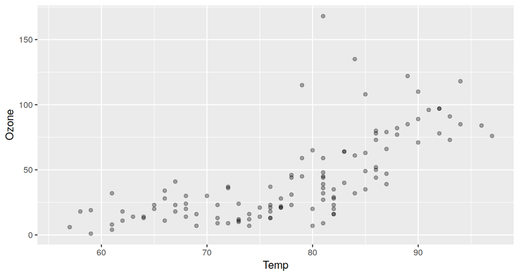

```r
ggplot(airquality, aes(x = Temp, y = Ozone)) +
  geom_point(alpha = 0.33)  # alpha of 0 is invisible, 1 is opaque
```

## Scatterplots

*Overplotting* can easily occur, especially with large data sets.

- happens when multiple data points are drawn on the same spot
- fix it with setting a semi-transparent fill color or apply *jittering*

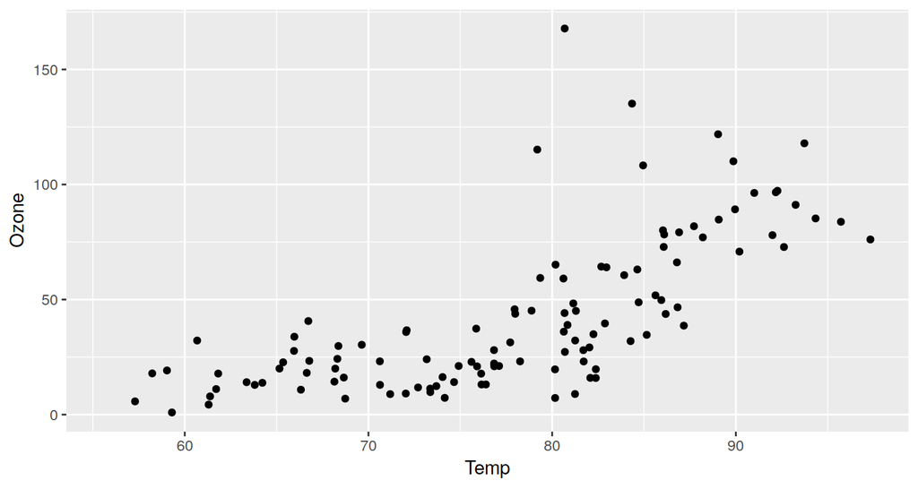

```r
ggplot(airquality, aes(x = Temp, y = Ozone)) +
  geom_point(position = position_jitter())
```

## Scatterplots

`geom_smooth()` aids the eye in seeing patterns by adding a (local polynomial) regression line and its confidence interval:

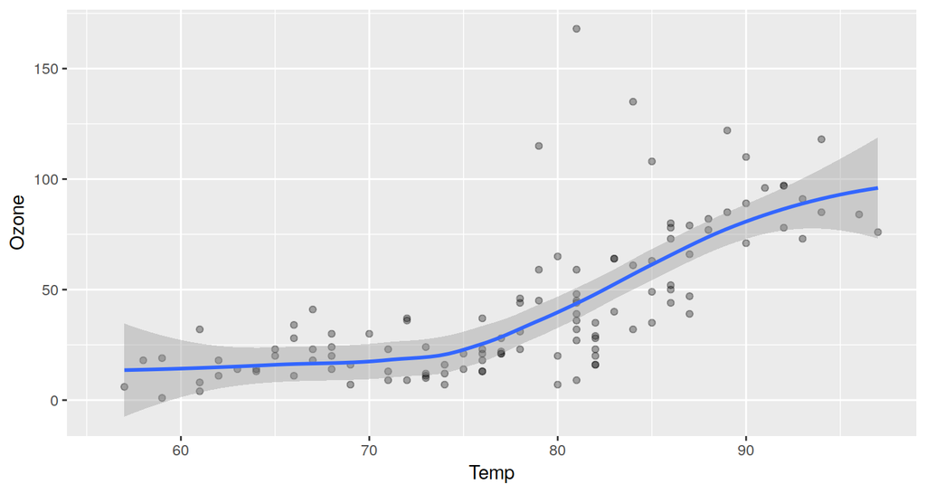

```r
ggplot(airquality, aes(x = Temp, y = Ozone)) +
  geom_point(alpha = 0.33) +
  geom_smooth()
```

## Line graphs

A *line graph* can be used whenever you have an **ordered numeric variable on the x-axis**, such as years.

We'll use a subset of the `presidentialElections` data set from the package *pscl*:

```r
(cal_pres <- presidentialElections %>% filter(state == 'California'))
```

```
## # A tibble: 22 x 4
##    state      demVote  year south
##    <chr>        <dbl> <int> <lgl>
##  1 California    58.4  1932 FALSE
##  2 California    67.0  1936 FALSE
##  3 California    57.4  1940 FALSE
##  4 California    56.5  1944 FALSE
##  5 California    47.6  1948 FALSE
##  6 California    42.7  1952 FALSE
##  7 California    44.3  1956 FALSE
##  8 California    49.6  1960 FALSE
##  9 California    59.1  1964 FALSE
## 10 California    44.7  1968 FALSE
## # ... with 12 more rows
```

## Line graphs

We map `year` on the x-axis, the vote share for Democrats `demVote` on the y-axis and add a `geom_line()` layer:

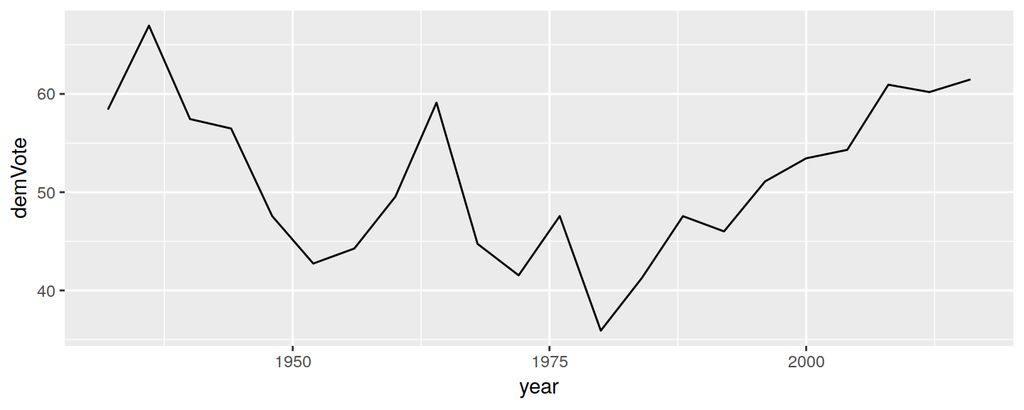

```r
ggplot(cal_pres, aes(x = year, y = demVote)) + geom_line()
```

## Line graphs

We can additionally add points like in a scatterplot:

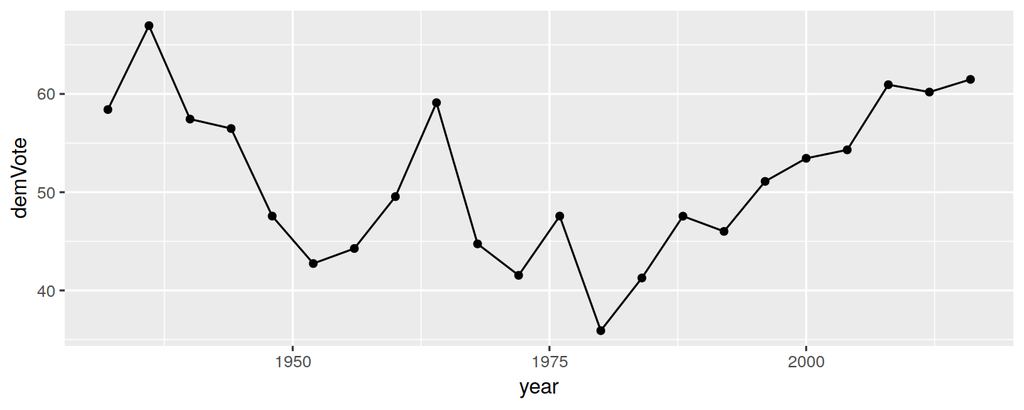

```r
ggplot(cal_pres, aes(x = year, y = demVote)) +
  geom_line() +
  geom_point()
```

## Line graphs

Again, we'll plot the historical election results from four states (data set `presidentialElections` from package *pscl*) stored in an object `sampled_pres`:

```
## # A tibble: 88 x 4
##    state        demVote  year south
##    <chr>          <dbl> <int> <lgl>
##  1 Louisiana       92.8  1932 TRUE
##  2 Maine           43.2  1932 FALSE
##  3 South Dakota    63.6  1932 FALSE
##  4 Tennessee       66.5  1932 TRUE
##  5 Louisiana       88.8  1936 TRUE
##  6 Maine           41.5  1936 FALSE
##  7 South Dakota    54.0  1936 FALSE
##  8 Tennessee       68.8  1936 TRUE
##  9 Louisiana       85.9  1940 TRUE
## 10 Maine           48.8  1940 FALSE
## # ... with 78 more rows
```

## Line graphs

If we simply use the same command as before, we produce some interesting chaos:

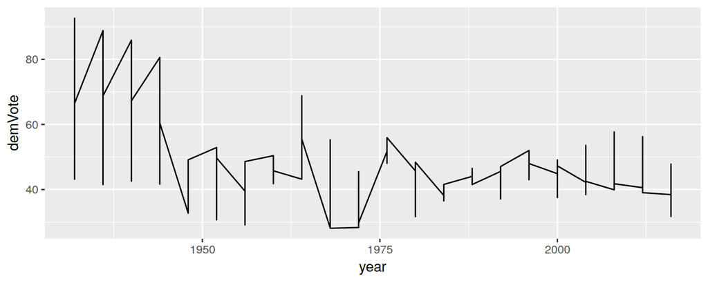

```r
ggplot(sampled_pres, aes(x = year, y = demVote)) + geom_line()
```

## Line graphs

We have to add another aesthetic mapping (`color = state`) in order to tell apart the states' lines:

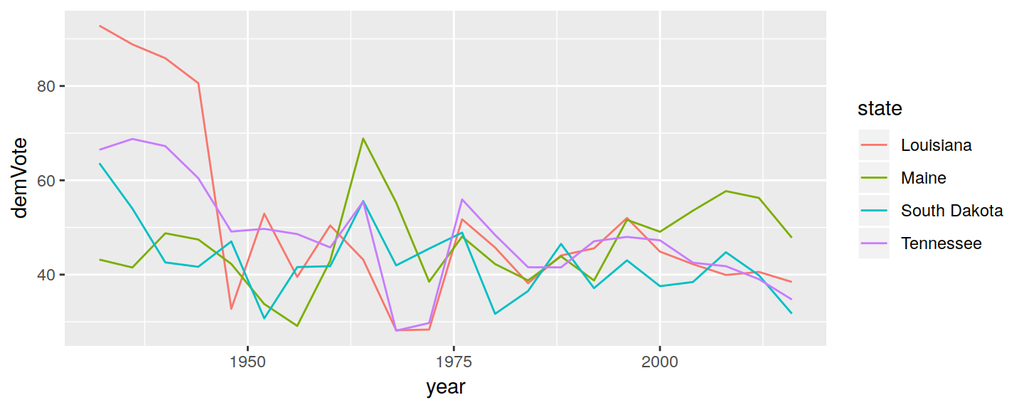

```r
ggplot(sampled_pres, aes(x = year, y = demVote, color = state)) + geom_line()
```

## Saving plots

A ggplot object can be assigned a name just as any other object in R:

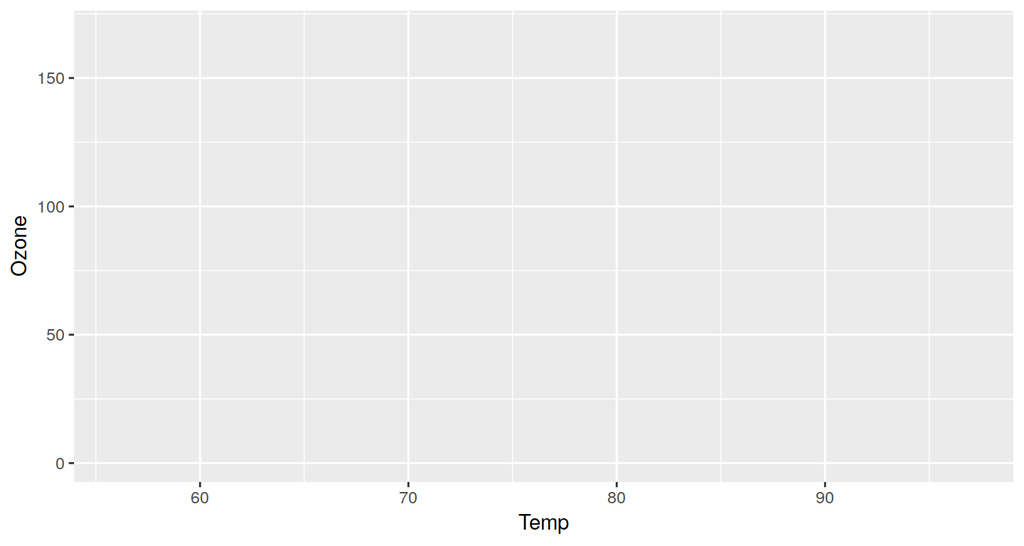

```r
myplot <- ggplot(airquality, aes(x = Temp, y = Ozone))
myplot   # shows an "empty" plot
```

## Saving plots

You can re-use the ggplot object and try out different layers:

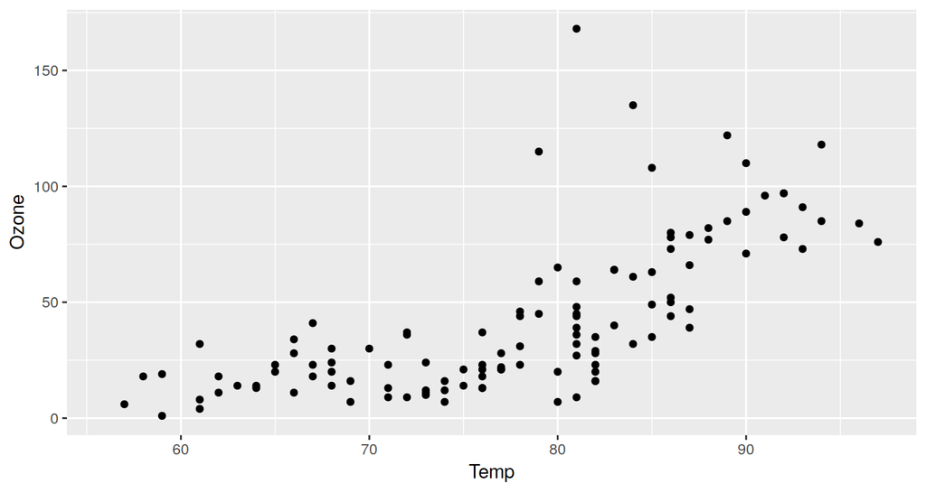

```r
myplot + geom_point()
```

## Saving plots

You can re-use the ggplot object and try out different layers or themes:

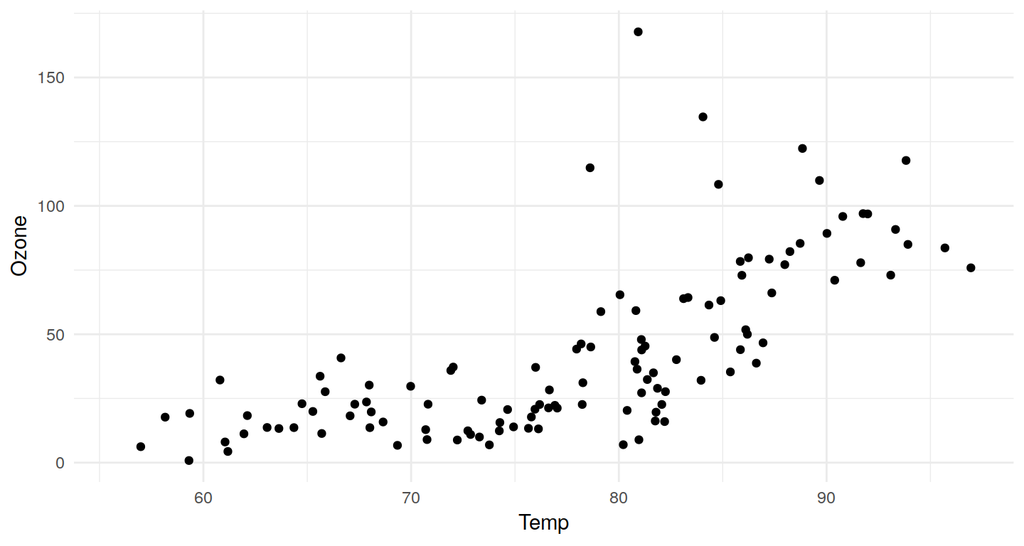

```r
myplot + geom_point(position = position_jitter()) + theme_minimal()
```

## Saving plots

You can eventually save the plot to disk with `ggsave()`:

```r
final_plot <- myplot + geom_point(position = position_jitter())
ggsave('07plotting-resources/example_saved_figure.png',
       plot = final_plot,
       width = 4,
       height = 3)
```

There are several options to configure the output file (see `?ggsave`):

- plot dimensions (by default in inch)
- plot resolution
- format (PNG, PDF, etc.) – determined by file extension

## Common mistakes

A very common mistake is to accidentally put `+` on a new line:

```r
ggplot(airquality, aes(x = Temp, y = Ozone))
  + geom_point()
```

`Error: Cannot use "+.gg()" with a single argument. Did you accidentally put + on a new line?`

The `+` operator must appear before the line break (the same is true for other operators like `%>%` used in *dplyr*):

```r
ggplot(airquality, aes(x = Temp, y = Ozone)) +
  geom_point()
```

## Common mistakes

The type of your variables determines its scale for plotting. E.g. here you might want to use a discrete scale:

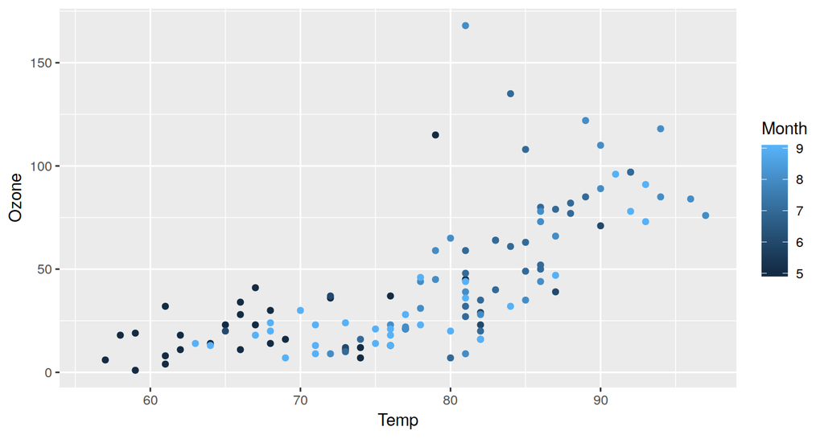

```r
ggplot(airquality, aes(x = Temp, y = Ozone, color = Month)) +
  geom_point()
```